# Machine Learning in mlr package

08 April, 2019

# Introduction

This is an R Markdown notebook for machine learning in mlr package. More details see mlr Github https://github.com/mlr-org/mlr.

# Examples

## Simple Example

```r
## 1) Define the task: Specify the type of analysis (e.g. classification) and provide data and response variable
task = makeClassifTask(data = iris, target = "Species")

## 2) Define the learner: Choose a specific algorithm (e.g. linear discriminant analysis)
lrn = makeLearner("classif.lda")
n = nrow(iris)
train.set = sample(n, size = 2/3*n)
test.set = setdiff(1:n, train.set)

## 3) Fit the model: Train the learner on the task using a random subset of the data as training set
model = train(lrn, task, subset = train.set)

## 4) Make predictions: Predict values of the response variable for new observations by the trained model, using the other part of the data as test set
pred = predict(model, task = task, subset = test.set)

## 5) Evaluate the learner: Calculate the mean misclassification error and accuracy
performance(pred, measures = list(mmce, acc))
```

```
## mmce  acc
##    0    1
```

## Examples for Classification

For classification the target column has to be a factor.

```r
df = getTaskData(sonar.task)
## Define the task
classifTask = makeClassifTask(data = df, target = "Class",positive = "M")
classifTask$task.desc
```

```
## $id
## [1] "df"
##
## $type
## [1] "classif"
##
## $target
## [1] "Class"
##
## $size
## [1] 208
##
## $n.feat
##    numerics     factors     ordered functionals
##          60           0           0           0
##
## $has.missings
## [1] FALSE
##
## $has.weights
## [1] FALSE
##
## $has.blocking
## [1] FALSE
##
## $has.coordinates
## [1] FALSE
##
## $class.levels
## [1] "M" "R"
##
## $positive
## [1] "M"
##
## $negative
## [1] "R"
##
## $class.distribution
##
##   M   R
## 111  97
##
## attr(,"class")
## [1] "ClassifTaskDesc"    "SupervisedTaskDesc" "TaskDesc"
```

```r
## Generate the learner
lrn = makeLearner("classif.rpart",predict.type = "prob")

## Train the learner
mod = train(lrn, classifTask)
mod = train("classif.rpart", classifTask) #Train the learner without generating it seperately
mod
```

```
## Model for learner.id=classif.rpart; learner.class=classif.rpart
## Trained on: task.id = df; obs = 208; features = 60
## Hyperparameters: xval=0
```

```r
## subset dataset for trainning
n = getTaskSize(classifTask)
trainSet = sample(n, size = n/3)
testSet=setdiff(1:n,train.set)
mod = train(lrn, classifTask, subset = trainSet)

## Calculate the observation with weights if the outcome has different numbers of 0 and 1
target = getTaskTargets(classifTask)
tab = as.numeric(table(target))
w = 1/tab[target]
mod = train(lrn, classifTask,weights = w)

## Prediction
taskPred = predict(mod, task = classifTask, subset = testSet)
taskPred
```

```
## Prediction: 108 observations
## predict.type: prob
## threshold: M=0.50,R=0.50
## time: 0.00
##    id truth     prob.M    prob.R response
## 9   9     R 0.09394023 0.9060598        R
## 10 10     R 0.09394023 0.9060598        R
## 11 11     R 0.09394023 0.9060598        R
## 16 16     R 0.00000000 1.0000000        R
## 17 17     R 0.00000000 1.0000000        R
## 20 20     R 0.28740741 0.7125926        R
## ... (#rows: 108, #cols: 5)
```

```r
newdataPred = predict(mod, newdata = df[testSet,which(colnames(df)!="Class")]) #if you want to predict data not included in the Task.
newdataPred #Please note there is no "truth" column as this new data don't have a outcome ("Class" here) column
```

```
## Prediction: 108 observations
## predict.type: prob
## threshold: M=0.50,R=0.50
## time: 0.00
##        prob.M    prob.R response
## 9  0.09394023 0.9060598        R
## 10 0.09394023 0.9060598        R
## 11 0.09394023 0.9060598        R
## 16 0.00000000 1.0000000        R
## 17 0.00000000 1.0000000        R
## 20 0.28740741 0.7125926        R
## ... (#rows: 108, #cols: 3)
```

```r
head(as.data.frame(taskPred))  #export prediction results as data.frame
```

```
##    id truth     prob.M    prob.R response
## 9   9     R 0.09394023 0.9060598        R
## 10 10     R 0.09394023 0.9060598        R
## 11 11     R 0.09394023 0.9060598        R
## 16 16     R 0.00000000 1.0000000        R
## 17 17     R 0.00000000 1.0000000        R
## 20 20     R 0.28740741 0.7125926        R
```

```r
head(getPredictionProbabilities(taskPred)) #get prediction probabilities. Please note the learner should have predict.type = "prob" as the default is "label"
```

```
## [1] 0.09394023 0.09394023 0.09394023 0.00000000 0.00000000 0.28740741
```

```r
head(getPredictionProbabilities(taskPred, cl = c("M", "R"))) #by default it is positive class probability. We can get both by this command
```

```
##             M         R
## 9  0.09394023 0.9060598
## 10 0.09394023 0.9060598
## 11 0.09394023 0.9060598
## 16 0.00000000 1.0000000
## 17 0.00000000 1.0000000
## 20 0.28740741 0.7125926
```

```r
calculateConfusionMatrix(taskPred,relative = TRUE) #Confusion matrix of Prediction
```

```
## Relative confusion matrix (normalized by row/column):
##         predicted
## true     M         R         -err.-
##   M      0.85/1.00 0.15/0.24 0.15
##   R      0.00/0.00 1.00/0.76 0.00
##   -err.-      0.00      0.24 0.10
##
##
## Absolute confusion matrix:
##         predicted
## true      M  R -err.-
##   M      62 11     11
##   R       0 35      0
##   -err.-  0 11     11
```

```r
## Adjusting the Prediction decision threshold
taskPred$threshold
```

```
##   M   R
## 0.5 0.5
```

```r
getTaskDesc(classifTask)$positive
```

```
## [1] "M"
```

```r
#Please note here this is threshold for the positive class. So probability < it will be negative class
taskPred1 = setThreshold(taskPred, 0.9)
calculateConfusionMatrix(taskPred)
```

```
##         predicted
## true      M  R -err.-
##   M      62 11     11
##   R       0 35      0
##   -err.-  0 11     11
```

```r
calculateConfusionMatrix(taskPred1)
```

```
##         predicted
## true      M  R -err.-
##   M      62 11     11
##   R       0 35      0
##   -err.-  0 11     11
```

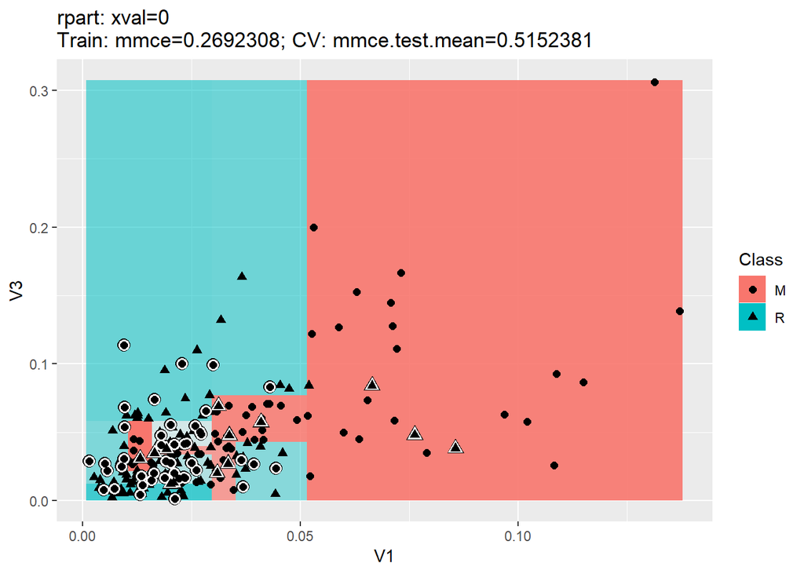

```r
## Visulization
lrn = makeLearner("classif.rpart")
plotLearnerPrediction(lrn, features = c("V1", "V3"),task = classifTask)
```

```r
## Calculate performance measures
performance(taskPred)
```

```
##      mmce
## 0.1018519
```

```r
performance(taskPred, measures = list(fpr, fnr, mmce,auc))
```

```
##       fpr       fnr      mmce       auc
## 0.0000000 0.1506849 0.1018519 0.9493151
```

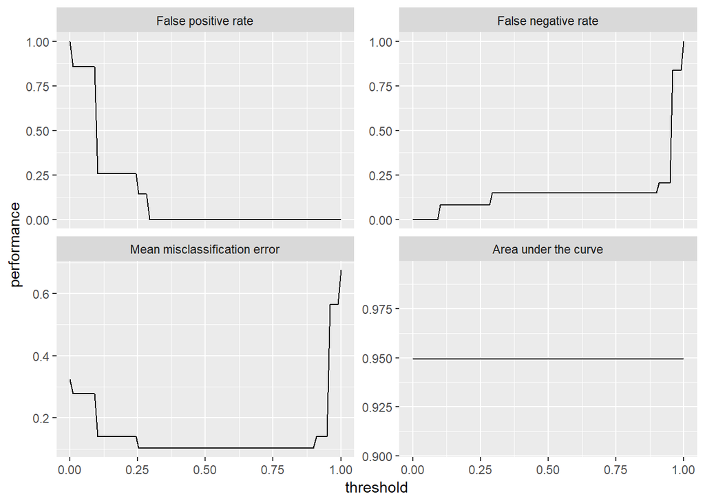

```r
d = generateThreshVsPerfData(taskPred, measures = list(fpr, fnr, mmce,auc))
plotThreshVsPerf(d) #Plot performance versus threshold
```

```r
r = calculateROCMeasures(taskPred) #ROC measures
r
```

```
##     predicted
## true M      R
##    M 62     11        tpr: 0.85 fnr: 0.15
##    R 0      35        fpr: 0    tnr: 1
##      ppv: 1 for: 0.24 lrp: Inf  acc: 0.9
##      fdr: 0 npv: 0.76 lrm: 0.15 dor: Inf
##
##
## Abbreviations:
## tpr - True positive rate (Sensitivity, Recall)
## fpr - False positive rate (Fall-out)
## fnr - False negative rate (Miss rate)
## tnr - True negative rate (Specificity)
## ppv - Positive predictive value (Precision)
## for - False omission rate
## lrp - Positive likelihood ratio (LR+)
## fdr - False discovery rate
## npv - Negative predictive value
## acc - Accuracy
## lrm - Negative likelihood ratio (LR-)
## dor - Diagnostic odds ratio
```

## Re-Sampling

- Cross-validation (“CV”),
- Leave-one-out cross-validation (“LOO”),
- Repeated cross-validation (“RepCV”),
- Out-of-bag bootstrap and other variants like b632 (“Bootstrap”),
- Subsampling, also called Monte-Carlo cross-validation (“Subsample”),
- Holdout (training/test) (“Holdout”).

More details at https://mlr-org.github.io/mlr-tutorial/release/html/resample/index.html

```r
## 3-fold cross-validation
rdesc = makeResampleDesc("CV", iters = 3)
rdesc
```

```
## Resample description: cross-validation with 3 iterations.
## Predict: test
## Stratification: FALSE
```

```r
cv3 #pre-defined resample descriptions: hout, cv3, cv5, cv10
```

```
## Resample description: cross-validation with 3 iterations.
## Predict: test
## Stratification: FALSE
```

```r
r = resample("classif.rpart", classifTask, rdesc)
```

```
## Resampling: cross-validation
```

```
## Measures:             mmce
```

```
## [Resample] iter 1:    0.2463768
```

```
## [Resample] iter 2:    0.2898551
```

```
## [Resample] iter 3:    0.2714286
```

```
## Aggregated Result: mmce.test.mean=0.2692202
```

```r
r
```

```
## Resample Result
## Task: df
## Learner: classif.rpart
## Aggr perf: mmce.test.mean=0.2692202
## Runtime: 0.0738401
```

```r
names(r)
```

```
##  [1] "learner.id"     "task.id"        "task.desc"      "measures.train"
##  [5] "measures.test"  "aggr"           "pred"           "models"
##  [9] "err.msgs"       "err.dumps"      "extract"        "runtime"
```

```r
r$measures.test
```

```
##   iter      mmce
## 1    1 0.2463768
## 2    2 0.2898551
## 3    3 0.2714286
```

```r
## Subsampling with 5 iterations and 4/5 training data
rdesc = makeResampleDesc("Subsample", iters = 5, split = 4/5)
lrn = makeLearner("classif.rpart", parms = list(split = "information")) ## Classification tree with information splitting criterion
r = resample(lrn, classifTask, rdesc, measures = list(mmce, fpr, fnr)) ## Calculate the performance measures
```

```
## Resampling: subsampling
```

```
## Measures:             mmce      fpr       fnr
```

```
## [Resample] iter 1:    0.3333333 0.5000000 0.1818182
```

```
## [Resample] iter 2:    0.1904762 0.2727273 0.1000000
```

```
## [Resample] iter 3:    0.2619048 0.0000000 0.4074074
```

```
## [Resample] iter 4:    0.2142857 0.1428571 0.2500000
```

```
## [Resample] iter 5:    0.2857143 0.4090909 0.1500000
```

```
## Aggregated Result: mmce.test.mean=0.2571429,fpr.test.mean=0.2649351,fnr.test.mean=0.2178451
```

```r
addRRMeasure(r, list(ber, timepredict)) #f you want to add further measures afterwards, use addRRMeasure
```

```
## Resample Result
## Task: df
## Learner: classif.rpart
## Aggr perf: mmce.test.mean=0.2571429,fpr.test.mean=0.2649351,fnr.test.mean=0.2178451,ber.test.mean=0.2413901,timepredict.test.mean=0.0100000
## Runtime: 0.149639
```

```r
#For convenience you can also specify the learner as a string and pass any learner parameters via the ... argument of resample.
r = resample("classif.rpart", parms = list(split = "information"), classifTask, rdesc, measures = list(mmce, fpr, fnr), show.info = FALSE)

## Accessing resample results
#Predections: By default, predictions are made for the test sets only
r$pred
```

```
## Resampled Prediction for:
## Resample description: subsampling with 5 iterations and 0.80 split rate.
## Predict: test
## Stratification: FALSE
## predict.type: response
## threshold:
## time (mean): 0.01
##    id truth response iter  set
## 1 187     M        R    1 test
## 2 177     M        M    1 test
## 3  79     R        R    1 test
## 4 181     M        M    1 test
## 5 146     M        M    1 test
## 6  91     R        R    1 test
## ... (#rows: 210, #cols: 5)
```

```r
pred = getRRPredictions(r) #same as r$pred
head(as.data.frame(pred))
```

```
##    id truth response iter  set
## 1 187     M        R    1 test
## 2 177     M        M    1 test
## 3  79     R        R    1 test
## 4 181     M        M    1 test
## 5 146     M        M    1 test
## 6  91     R        R    1 test
```

```r
head(getPredictionTruth(pred))
```

```
## [1] M M R M M R
## Levels: M R
```

```r
head(getPredictionResponse(pred))
```

```
## [1] R M R M M R
## Levels: M R
```

```r
#Make predictions on both training and test sets
rdesc = makeResampleDesc("Holdout", predict = "both")
r = resample("classif.lda", classifTask, rdesc, show.info = FALSE)
r
```

```
## Resample Result
## Task: df
## Learner: classif.lda
## Aggr perf: mmce.test.mean=0.2000000
## Runtime: 0.029959
```

```r
r$measures.train #Please note that nonetheless the misclassification rate r$aggr is estimated on the test data only
```

```
##   iter      mmce
## 1    1 0.0942029
```

```r
predList = getRRPredictionList(r) #getRRPredictionList which returns a list of predictions split by data set (train/test) and resampling iteration.
predList
```

```
## $train
## $train$`1`
## Prediction: 138 observations
## predict.type: response
## threshold:
## time: 0.00
##      id truth response
## 99   99     M        M
## 187 187     M        M
## 12   12     R        R
## 207 207     M        M
## 22   22     R        R
## 104 104     M        M
## ... (#rows: 138, #cols: 3)
##
##
## $test
## $test$`1`
## Prediction: 70 observations
## predict.type: response
## threshold:
## time: 0.00
##      id truth response
## 182 182     M        M
## 160 160     M        R
## 92   92     R        R
## 7     7     R        R
## 17   17     R        R
## 4     4     R        M
## ... (#rows: 70, #cols: 3)
```

### The extract option

we extract the variable importances from fitted regression trees using function getFeatureImportance.

```r
r = resample("classif.rpart", classifTask, rdesc, show.info = FALSE, extract = getFeatureImportance)
r$extract[1:2]
```

```
## [[1]]
## FeatureImportance:
## Task: df
##
## Learner: classif.rpart
## Measure: NA
## Contrast: NA
## Aggregation: function (x)  x
## Replace: NA
## Number of Monte-Carlo iterations: NA
## Local: FALSE
##         V1 V2 V3       V4 V5       V6 V7 V8       V9      V10      V11
## 1 3.299024  0  0 3.665582  0 4.933368  0  0 5.591151 7.564498 11.84008
##        V12      V13 V14      V15     V16 V17     V18      V19      V20
## 1 18.08902 9.866737   0 4.771433 4.29429   0 2.25951 3.615216 4.519019
##        V21      V22 V23 V24 V25      V26      V27      V28      V29 V30
## 1 5.874725 3.615216   0   0   0 5.964291 9.304294 9.501887 4.771433   0
##        V31 V32 V33 V34 V35 V36 V37 V38 V39 V40      V41      V42      V43
## 1 1.807608   0   0   0   0   0   0   0   0   0 1.502952 2.630166 3.381643
##   V44 V45 V46 V47 V48      V49      V50      V51 V52 V53 V54      V55 V56
## 1   0   0   0   0   0 1.502952 1.502952 7.697723   0   0   0 3.299024   0
##   V57      V58      V59 V60
## 1   0 2.254428 4.398699   0
##
## [[2]]
## NULL
```

### Stratification and blocking

- In order to conduct stratified resampling, set stratify = TRUE in makeResampleDesc. Stratification is also available for survival tasks. The stratification balances the censoring rate.
- If it is required to also stratify on the input data, e.g., to ensure that all subgroups are represented in all training and test sets. To stratify on the input columns, specify factor columns of your task data via stratify.cols.
- If some observations “belong together” and must not be separated when splitting the data into training and test sets for resampling, you can supply this information via a blocking factor when creating the task.
- Resample instances readily allow for paired experiments, that is comparing the performance of several learners on exactly the same training and test sets.

```r
#Stratification with respect to the target variable(s)
rdesc = makeResampleDesc("CV", iters = 3, stratify = TRUE)
r = resample("classif.lda", classifTask, rdesc, show.info = FALSE)
r
```

```
## Resample Result
## Task: df
## Learner: classif.lda
## Aggr perf: mmce.test.mean=0.2838509
## Runtime: 0.0718081
```

```r
#Sometimes it is required to also stratify on the input data
rdesc = makeResampleDesc("CV", iters = 3, stratify.cols = "chas")
r = resample("regr.rpart", bh.task, rdesc, show.info = FALSE)
r
```

```
## Resample Result
## Task: BostonHousing-example
## Learner: regr.rpart
## Aggr perf: mse.test.mean=20.9197315
## Runtime: 0.0359042
```

```r
#5 blocks containing 30 observations each
task = makeClassifTask(data = iris, target = "Species", blocking = factor(rep(1:5, each = 30)))
task
```

```
## Supervised task: iris
## Type: classif
## Target: Species
## Observations: 150
## Features:
##    numerics     factors     ordered functionals
##           4           0           0           0
## Missings: FALSE
## Has weights: FALSE
## Has blocking: TRUE
## Has coordinates: FALSE
## Classes: 3
##     setosa versicolor  virginica
##         50         50         50
## Positive class: NA
```

```r
#Resample descriptions and resample instances
rdesc = makeResampleDesc("CV", iters = 3)
rin = makeResampleInstance(rdesc, iris.task)
rin #Please note there is only resample index information
```

```
## Resample instance for 150 cases.
## Resample description: cross-validation with 3 iterations.
## Predict: test
## Stratification: FALSE
```

```r
rin = makeResampleInstance(rdesc, size = nrow(iris))
#Resample instances readily allow for paired experiments
rdesc = makeResampleDesc("CV", iters = 3)
rin = makeResampleInstance(rdesc, task = iris.task)
r.lda = resample("classif.lda", iris.task, rin, show.info = FALSE)
r.rpart = resample("classif.rpart", iris.task, rin, show.info = FALSE)
r.lda$aggr
```

```
## mmce.test.mean
##     0.03333333
```

```r
r.rpart$aggr
```

```
## mmce.test.mean
##     0.05333333
```

### Aggregating performance values

Each performance Measure in mlr has a corresponding default aggregation method which is stored in slot $aggr. The default aggregation for most measures is test.mean. One exception is the root mean square error (rmse). The aggregation schemes test.median, test.min, and test.max compute the median, minimum, and maximum of the performance values on the test sets.

```r
mmce$aggr
```

```
## Aggregation function: test.mean
```

```r
mmce$aggr$fun
```

```
## function (task, perf.test, perf.train, measure, group, pred)
## mean(perf.test)
## <bytecode: 0x0000000023b200c8>
## <environment: namespace:mlr>
```

```r
rmse$aggr
```

```
## Aggregation function: test.rmse
```

```r
rmse$aggr$fun
```

```
## function (task, perf.test, perf.train, measure, group, pred)
## sqrt(mean(perf.test^2))
## <bytecode: 0x00000000389bc350>
## <environment: namespace:mlr>
```

```r
#Example: One measure with different aggregations
mseTestMedian = setAggregation(mse, test.median)
mseTestMin = setAggregation(mse, test.min)
mseTestMax = setAggregation(mse, test.max)
rdesc = makeResampleDesc("CV", iters = 3)
r = resample("regr.lm", bh.task, rdesc, measures = list(mse, mseTestMedian, mseTestMin, mseTestMax))
```

```
## Resampling: cross-validation
```

```
## Measures:             mse       mse       mse       mse
```

```
## [Resample] iter 1:    21.474301921.474301921.474301921.4743019
```

```
## [Resample] iter 2:    20.059058920.059058920.059058920.0590589
```

```
## [Resample] iter 3:    30.968410530.968410530.968410530.9684105
```

```
## Aggregated Result: mse.test.mean=24.1672571,mse.test.median=21.4743019,mse.test.min=20.0590589,mse.test.max=30.9684105
```

```r
r
```

```
## Resample Result
## Task: BostonHousing-example
## Learner: regr.lm
## Aggr perf: mse.test.mean=24.1672571,mse.test.median=21.4743019,mse.test.min=20.0590589,mse.test.max=30.9684105
## Runtime: 0.0349021
```

```r
r$aggr
```

```
##   mse.test.mean mse.test.median    mse.test.min    mse.test.max
##        24.16726        21.47430        20.05906        30.96841
```

```r
#Example: Bootstrap
#The b632 and b632+ variants calculate a convex combination of the training performance and the out-of-bag bootstrap performance and thus require predictions on the training sets and an appropriate aggregation strategy.
rdesc = makeResampleDesc("Bootstrap", predict = "both", iters = 10)
mmceB632 = setAggregation(mmce, b632)
mmceB632plus = setAggregation(mmce, b632plus)
r = resample("classif.rpart", iris.task, rdesc, measures = list(mmce, mmceB632, mmceB632plus),show.info = FALSE)
head(r$measures.train)
```

```
##   iter        mmce        mmce        mmce
## 1    1 0.033333333 0.033333333 0.033333333
## 2    2 0.020000000 0.020000000 0.020000000
## 3    3 0.040000000 0.040000000 0.040000000
## 4    4 0.013333333 0.013333333 0.013333333
## 5    5 0.006666667 0.006666667 0.006666667
## 6    6 0.033333333 0.033333333 0.033333333
```

```r
## Compare misclassification rates for out-of-bag, b632, and b632+ bootstrap
r$aggr
```

```
## mmce.test.mean      mmce.b632  mmce.b632plus
##     0.07165236     0.05338029     0.05466411
```

### Convenience functions

- mlr includes some pre-defined resample description objects for frequently used strategies like, e.g., 5-fold cross-validation (cv5).
- Moreover, mlr provides special functions for the most common resampling methods, for example holdout, crossval, or bootstrapB632.

```r
crossval("classif.lda", iris.task, iters = 3, measures = list(mmce, ber))
```

```
## Resampling: cross-validation
```

```
## Measures:             mmce      ber
```

```
## [Resample] iter 1:    0.0400000 0.0376984
```

```
## [Resample] iter 2:    0.0400000 0.0413534
```

```
## [Resample] iter 3:    0.0200000 0.0277778
```

```
## Aggregated Result: mmce.test.mean=0.0333333,ber.test.mean=0.0356099
```

```
## Resample Result
## Task: iris-example
## Learner: classif.lda
## Aggr perf: mmce.test.mean=0.0333333,ber.test.mean=0.0356099
## Runtime: 0.0447071
```

```r
bootstrapB632plus("regr.lm", bh.task, iters = 3, measures = list(mse, mae))
```

```
## Resampling: OOB bootstrapping
```

```
## Measures:             mse.train   mae.train   mse.test    mae.test
```

```
## [Resample] iter 1:    24.1221416  3.3962734   23.9553433  3.5841997
```

```
## [Resample] iter 2:    18.1634887  3.0941743   29.0697536  3.4727344
```

```
## [Resample] iter 3:    23.2703487  3.4229829   19.3479165  3.3176266
```

```
## Aggregated Result: mse.b632plus=23.3755602,mae.b632plus=3.4041129
```

```
## Resample Result
## Task: BostonHousing-example
## Learner: regr.lm
## Aggr perf: mse.b632plus=23.3755602,mae.b632plus=3.4041129
## Runtime: 0.060818
```

## Benchmark

### Conducting benchmark experiments

```r
## Two learners to be compared
lrns = list(makeLearner("classif.lda"), makeLearner("classif.rpart"))
## Choose the resampling strategy
rdesc = makeResampleDesc("Holdout")
## Conduct the benchmark experiment
bmr = benchmark(lrns, sonar.task, rdesc)
```

```
## Task: Sonar-example, Learner: classif.lda
```

```
## Resampling: holdout
```

```
## Measures:             mmce
```

```
## [Resample] iter 1:    0.3428571
```

```
## Aggregated Result: mmce.test.mean=0.3428571
```

```
## Task: Sonar-example, Learner: classif.rpart
```

```
## Resampling: holdout
```

```
## Measures:             mmce
```

```
## [Resample] iter 1:    0.2857143
```

```
## Aggregated Result: mmce.test.mean=0.2857143
```

```r
bmr
```

```
##         task.id    learner.id mmce.test.mean
## 1 Sonar-example   classif.lda      0.3428571
## 2 Sonar-example classif.rpart      0.2857143
```

#### Accessing benchmark results

mlr provides several accessor functions, named getBMR, that permit to retrieve information for further analyses.

```r
getBMRPerformances(bmr) #returns individual performances in resampling runs
```

```
## $`Sonar-example`
## $`Sonar-example`$classif.lda
##   iter      mmce
## 1    1 0.3428571
##
## $`Sonar-example`$classif.rpart
##   iter      mmce
## 1    1 0.2857143
```

```r
getBMRAggrPerformances(bmr) #gives the aggregated values
```

```
## $`Sonar-example`
## $`Sonar-example`$classif.lda
## mmce.test.mean
##      0.3428571
##
## $`Sonar-example`$classif.rpart
## mmce.test.mean
##      0.2857143
```

```r
#Often it is more convenient to work with data.frames. You can easily convert the result structure by setting as.df = TRUE.
getBMRPerformances(bmr, as.df = TRUE)
```

```
##         task.id    learner.id iter      mmce
## 1 Sonar-example   classif.lda    1 0.3428571
## 2 Sonar-example classif.rpart    1 0.2857143
```

```r
getBMRAggrPerformances(bmr, as.df = TRUE)
```

```
##         task.id    learner.id mmce.test.mean
## 1 Sonar-example   classif.lda      0.3428571
## 2 Sonar-example classif.rpart      0.2857143
```

#### Predictions

You can access the predictions using function getBMRPredictions. Per default, you get a nested list of ResamplePrediction objects. As above, you can use the drop or as.df options to simplify the result.

```r
head(getBMRPredictions(bmr, as.df = TRUE))
```

```
##         task.id  learner.id  id truth response iter  set
## 1 Sonar-example classif.lda  92     R        R    1 test
## 2 Sonar-example classif.lda 100     M        R    1 test
## 3 Sonar-example classif.lda  84     R        M    1 test
## 4 Sonar-example classif.lda 103     M        M    1 test
## 5 Sonar-example classif.lda  96     R        R    1 test
## 6 Sonar-example classif.lda 106     M        M    1 test
```

```r
#It is also easily possible to access results for certain learners or tasks via their IDs.
head(getBMRPredictions(bmr, learner.ids = "classif.rpart", as.df = TRUE))
```

```
##         task.id    learner.id  id truth response iter  set
## 1 Sonar-example classif.rpart  92     R        M    1 test
## 2 Sonar-example classif.rpart 100     M        R    1 test
## 3 Sonar-example classif.rpart  84     R        R    1 test
## 4 Sonar-example classif.rpart 103     M        M    1 test
## 5 Sonar-example classif.rpart  96     R        R    1 test
## 6 Sonar-example classif.rpart 106     M        R    1 test
```

#### IDs

The IDs of all Learners, Tasks and Measures in a benchmark experiment can be retrieved as follows:

```r
getBMRTaskIds(bmr)
```

```
## [1] "Sonar-example"
```

```r
getBMRLearnerIds(bmr)
```

```
## [1] "classif.lda"   "classif.rpart"
```

```r
getBMRMeasureIds(bmr)
```

```
## [1] "mmce"
```

#### Fitted models

The fitted models can be retrieved by function getBMRModels. It returns a (possibly nested) list of WrappedModel objects.

```r
getBMRModels(bmr, drop = TRUE)
```

```
## $classif.lda
## $classif.lda[[1]]
## Model for learner.id=classif.lda; learner.class=classif.lda
## Trained on: task.id = Sonar-example; obs = 138; features = 60
## Hyperparameters:
##
##
## $classif.rpart
## $classif.rpart[[1]]
## Model for learner.id=classif.rpart; learner.class=classif.rpart
## Trained on: task.id = Sonar-example; obs = 138; features = 60
## Hyperparameters: xval=0
```

```r
getBMRModels(bmr, learner.ids = "classif.lda")
```

```
## $`Sonar-example`
## $`Sonar-example`$classif.lda
## $`Sonar-example`$classif.lda[[1]]
## Model for learner.id=classif.lda; learner.class=classif.lda
## Trained on: task.id = Sonar-example; obs = 138; features = 60
## Hyperparameters:
```

#### Learners and measures

```r
getBMRLearners(bmr)
```

```
## $classif.lda
## Learner classif.lda from package MASS
## Type: classif
## Name: Linear Discriminant Analysis; Short name: lda
## Class: classif.lda
## Properties: twoclass,multiclass,numerics,factors,prob
## Predict-Type: response
## Hyperparameters:
##
##
## $classif.rpart
## Learner classif.rpart from package rpart
## Type: classif
## Name: Decision Tree; Short name: rpart
## Class: classif.rpart
## Properties: twoclass,multiclass,missings,numerics,factors,ordered,prob,weights,featimp
## Predict-Type: response
## Hyperparameters: xval=0
```

```r
getBMRMeasures(bmr)
```

```
## [[1]]
## Name: Mean misclassification error
## Performance measure: mmce
## Properties: classif,classif.multi,req.pred,req.truth
## Minimize: TRUE
## Best: 0; Worst: 1
## Aggregated by: test.mean
## Arguments:
## Note: Defined as: mean(response != truth)
```

#### Merging benchmark results

You can perform an additional benchmark experiment and then use function mergeBenchmarkResults to combine the results to a single BenchmarkResult object that can be accessed and analyzed as usual.

```r
## First benchmark result
bmr
```

```
##         task.id    learner.id mmce.test.mean
## 1 Sonar-example   classif.lda      0.3428571
## 2 Sonar-example classif.rpart      0.2857143
```

```r
## Benchmark experiment for the additional learners
lrns2 = list(makeLearner("classif.randomForest"), makeLearner("classif.qda"))
bmr2 = benchmark(lrns2, sonar.task, rdesc, show.info = FALSE)
bmr2
```

```
##         task.id           learner.id mmce.test.mean
## 1 Sonar-example classif.randomForest      0.2000000
## 2 Sonar-example          classif.qda      0.3571429
```

```r
## Merge the results
bmr3=mergeBenchmarkResults(list(bmr, bmr2))
bmr3
```

```
##         task.id           learner.id mmce.test.mean
## 1 Sonar-example          classif.lda      0.3428571
## 2 Sonar-example        classif.rpart      0.2857143
## 3 Sonar-example classif.randomForest      0.2000000
## 4 Sonar-example          classif.qda      0.3571429
```

```r
perf = getBMRPerformances(bmr3, as.df = TRUE)
head(perf)
```

```
##         task.id           learner.id iter      mmce
## 1 Sonar-example          classif.lda    1 0.3428571
## 2 Sonar-example        classif.rpart    1 0.2857143
## 3 Sonar-example classif.randomForest    1 0.2000000
## 4 Sonar-example          classif.qda    1 0.3571429
```

### Benchmark analysis and visualization

#### Example: Comparing lda, rpart and random Forest

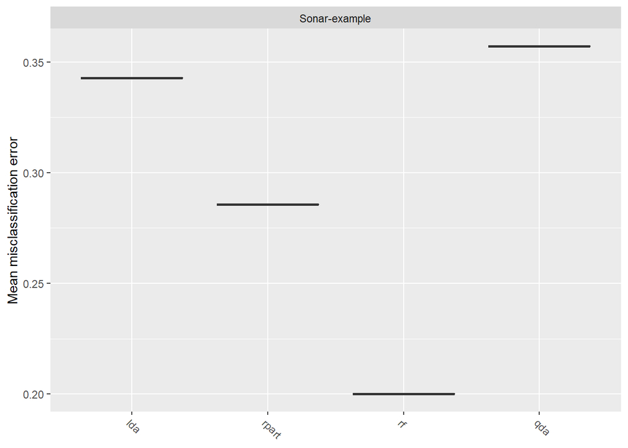

```r
plotBMRBoxplots(bmr3, measure = mmce)
```

## Feature Selection

Two tasks:

- Sort Features by importanceand filter Features with low importance;
- Feature subsets Selection;

### Basical functions for filter features

There are several ways to select a feature subset based on feature importance values:

- Keep a certain absolute number (abs) of features with highest importance.
- Keep a certain percentage (perc) of features with highest importance.
- Keep all features whose importance exceeds a certain threshold value (threshold).

Methods can be used in calculating the feature importance, see https://mlr-org.github.io/mlr-tutorial/release/html/filter_methods/index.html

Please note this methods are only related data itself, so it is applied before ML learning and will only be influenced by re-sampling. They will NOT be influenced by ML methods (learners) used in the model. So in each iter of resampling, all learners are using the same subset of features. Only the method intruduced in “Wrapper methods” and “feature selection” will be influenced by different ML methods.

```r
#Calculating the feature importance
fv = generateFilterValuesData(classifTask, method = "information.gain")
fv
```

```
## FilterValues:
## Task: df
##   name    type information.gain
## 1   V1 numeric       0.00000000
## 2   V2 numeric       0.00000000
## 3   V3 numeric       0.00000000
## 4   V4 numeric       0.05380378
## 5   V5 numeric       0.05024065
## 6   V6 numeric       0.00000000
## ... (#rows: 60, #cols: 3)
```

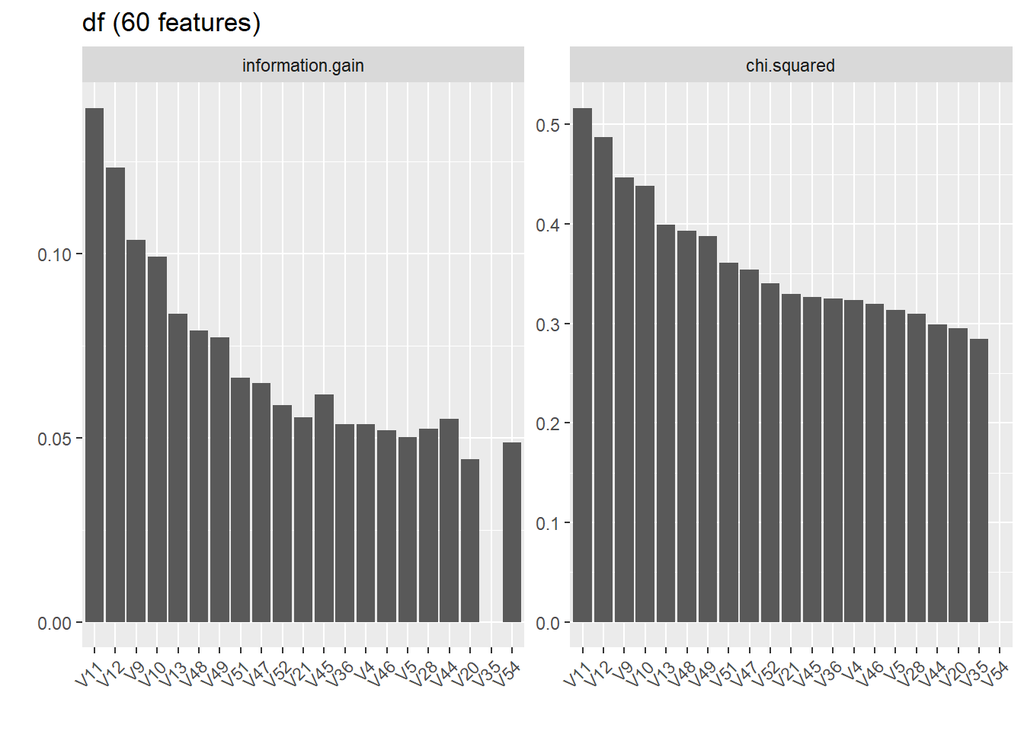

```r
fv2 = generateFilterValuesData(classifTask, method = c("information.gain", "chi.squared"))
plotFilterValues(fv2)
```

```r
#Selecting a feature subset
##Can either specify the method for calculating the feature importance or you can use previously computed importance values via argument fval
## Keep the 2 most important features
filteredTask = filterFeatures(classifTask, method = "information.gain", abs = 2)
## Keep the 25% most important features
filteredTask = filterFeatures(classifTask, fval = fv, perc = 0.25)
## Keep all features with importance greater than 0.5
filteredTask = filterFeatures(classifTask, fval = fv, threshold = 0.5)
filteredTask
```

```
## Supervised task: df
## Type: classif
## Target: Class
## Observations: 208
## Features:
##    numerics     factors     ordered functionals
##           0           0           0           0
## Missings: FALSE
## Has weights: FALSE
## Has blocking: FALSE
## Has coordinates: FALSE
## Classes: 2
##   M   R
## 111  97
## Positive class: M
```

### Fuse a learner with a filter method

```r
lrn = makeFilterWrapper(learner = "classif.rpart", fw.method = "information.gain", fw.abs = 3)
rdesc = makeResampleDesc("CV", iters = 10)
r = resample(learner = lrn, task = classifTask, resampling = rdesc, show.info = FALSE, models = TRUE)
r$aggr
```

```
## mmce.test.mean
##      0.2835714
```

```r
#which features have been used
sfeats = sapply(r$models, getFilteredFeatures)
table(sfeats)
```

```
## sfeats
## V10 V11 V12  V9
##   4  10  10   6
```

### Wrapper methods

Wrapper methods use the performance of a learning algorithm to assess the usefulness of a feature set.In order to use the wrapper approach we have to decide:

- How to assess the performance: This involves choosing a performance measure that serves as feature selection criterion and a resampling strategy.
- Which learning method to use.
- How to search the space of possible feature subsets.

The following search strategies are available:

- Exhaustive search (makeFeatSelControlExhaustive),
- Genetic algorithm (makeFeatSelControlGA),
- Random search (makeFeatSelControlRandom),
- Deterministic forward or backward search (makeFeatSelControlSequential).

```r
## Specify the search strategy
ctrl = makeFeatSelControlRandom(maxit = 20L)
ctrl
```

```
## FeatSel control: FeatSelControlRandom
## Same resampling instance: TRUE
## Imputation value: <worst>
## Max. features: <not used>
## Max. iterations: 20
## Tune threshold: FALSE
## Further arguments: prob=0.5
```

```r
rdesc = makeResampleDesc("Holdout")
sfeats = selectFeatures(learner = "classif.lda", task =classifTask, resampling = rdesc, control = ctrl, show.info = FALSE)
sfeats
```

```
## FeatSel result:
## Features (32): V2, V4, V5, V8, V9, V12, V13, V16, V20, V21, V22, V23, V28, V30, V31, V33, V34, V35, V36, V37, V39, V40, V41, V44, V47, V49, V50, V51, V54, V57, V58, V59
## mmce.test.mean=0.1571429
```

```r
sfeats$x
```

```
##  [1] "V2"  "V4"  "V5"  "V8"  "V9"  "V12" "V13" "V16" "V20" "V21" "V22"
## [12] "V23" "V28" "V30" "V31" "V33" "V34" "V35" "V36" "V37" "V39" "V40"
## [23] "V41" "V44" "V47" "V49" "V50" "V51" "V54" "V57" "V58" "V59"
```

```r
ctrl = makeFeatSelControlSequential(method = "sfs", alpha = 0.02)
rdesc = makeResampleDesc("CV", iters = 5)
sfeats = selectFeatures(learner = "classif.lda", task = classifTask, resampling = rdesc, control = ctrl,  show.info = FALSE)
analyzeFeatSelResult(sfeats)
```

```
## Features         : 2
## Performance      : mmce.test.mean=0.2306620
## V11, V49
##
## Path to optimum:
## - Features:    0  Init   :                       Perf = 0.48037  Diff: NA  *
## - Features:    1  Add    : V11                   Perf = 0.27851  Diff: 0.20186  *
## - Features:    2  Add    : V49                   Perf = 0.23066  Diff: 0.047851  *
##
## Stopped, because no improving feature was found.
```

### Fuse a learner with feature selection

```r
rdesc = makeResampleDesc("CV", iters = 3)
lrn = makeFeatSelWrapper("surv.coxph", resampling = rdesc,control = makeFeatSelControlRandom(maxit = 10,max.features = 5), show.info = FALSE)
mod = train(lrn, task = wpbc.task)
mod
```

```
## Model for learner.id=surv.coxph.featsel; learner.class=FeatSelWrapper
## Trained on: task.id = wpbc-example; obs = 194; features = 32
## Hyperparameters:
```

```r
sfeats = getFeatSelResult(mod)
sfeats
```

```
## FeatSel result:
## Features (5): mean_fractaldim, SE_fractaldim, worst_compactness, tsize, pnodes
## cindex.test.mean=0.6704042
```

```r
sfeats$x
```

```
## [1] "mean_fractaldim"   "SE_fractaldim"     "worst_compactness"
## [4] "tsize"             "pnodes"
```

```r
#cross-validated performance of the learner
r = resample(learner = lrn, task = wpbc.task, resampling = rdesc, models = TRUE,  show.info = FALSE)
r$aggr
```

```
## cindex.test.mean
##        0.6520146
```

```r
#selected feature sets in the individual resampling iterations can be extracted
lapply(r$models, getFeatSelResult)[1:2]
```

```
## [[1]]
## FeatSel result:
## Features (5): mean_texture, mean_compactness, mean_fractaldim, SE_texture, worst_compactness
## cindex.test.mean=0.7153858
##
## [[2]]
## FeatSel result:
## Features (5): SE_texture, SE_smoothness, worst_perimeter, worst_concavepoints, tsize
## cindex.test.mean=0.6586334
```

### export feature filter or selection results from benchmark object

```r
#If only one learner
#selectedFeatures<-lapply(getBMRModels(testSelection,drop=TRUE),getFeatSelResult)
#If more than one learner
#selectedFeatures<-lapply(getBMRModels(testSelection,drop=TRUE)[[1]],getFeatSelResult)

#filteredFeatures<-lapply(getBMRModels(testSelection,drop=TRUE),getFilteredFeatures)
```

## Other functions

### getLearnerModel: Get underlying R model of learner integrated into mlr

```r
#temp<-getFeatureImportance(bmr$results$Test$classif.rpart.filtered$models,more.unwrap=TRUE)
#temp
#Then you can use other functions designed for these underlying R models. For example, here rpart.plot for plottting desicion tree
#rpart.plot(temp)
```

### getFeatureImportance: Calculates feature importance values for trained models

Only for some learners which are possible to calculate feature importance measures. getFeatureImportance extracts those values from trained models.

- boosting;
- cforest;
- gbm;
- randomForest;
- RRF;
- randomForestSRC;
- ranger;
- rpart;
- xgboost;

Seems like only works with normal benchmark object. Can’t run with feature selection benchmark object.

```r
#getFeatureImportance(getBMRModels(bmr, learner.ids = "classif.rpart",drop = TRUE)[[1]])

#Not run
#getFeatureImportance(getBMRModels(bmr1, learner.ids = "classif.rpart.filtered",drop = TRUE)[[1]])
#no applicable method for 'getFeatureImportanceLearner' applied to an object of class "c('FilterWrapper', 'BaseWrapper', 'Learner')"
```

# More details

## glmnet

More details at https://github.com/mlr-org/mlr/issues/1030

```r
lrn=makeLearner("regr.glmnet")
getParamSet(lrn)
```

```
##                               Type  len      Def           Constr Req
## family                    discrete    - gaussian gaussian,poisson   -
## alpha                      numeric    -        1           0 to 1   -
## s                          numeric    -        -         0 to Inf   -
## exact                      logical    -    FALSE                -   -
## nlambda                    integer    -      100         1 to Inf   -
## lambda.min.ratio           numeric    -        -           0 to 1   -
## lambda               numericvector <NA>        -         0 to Inf   -
## standardize                logical    -     TRUE                -   -
## intercept                  logical    -     TRUE                -   -
## thresh                     numeric    -    1e-07         0 to Inf   -
## dfmax                      integer    -        -         0 to Inf   -
## pmax                       integer    -        -         0 to Inf   -
## exclude              integervector <NA>        -         1 to Inf   -
## penalty.factor       numericvector <NA>        -           0 to 1   -
## lower.limits         numericvector <NA>        -        -Inf to 0   -
## upper.limits         numericvector <NA>        -         0 to Inf   -
## maxit                      integer    -   100000         1 to Inf   -
## type.gaussian             discrete    -        - covariance,naive   -
## standardize.response       logical    -    FALSE                -   -
## fdev                       numeric    -    1e-05           0 to 1   -
## devmax                     numeric    -    0.999           0 to 1   -
## eps                        numeric    -    1e-06           0 to 1   -
## big                        numeric    -  9.9e+35      -Inf to Inf   -
## mnlam                      integer    -        5         1 to Inf   -
## pmin                       numeric    -    1e-09           0 to 1   -
## exmx                       numeric    -      250      -Inf to Inf   -
## prec                       numeric    -    1e-10      -Inf to Inf   -
## mxit                       integer    -      100         1 to Inf   -
##                      Tunable Trafo
## family                  TRUE     -
## alpha                   TRUE     -
## s                       TRUE     -
## exact                   TRUE     -
## nlambda                 TRUE     -
## lambda.min.ratio        TRUE     -
## lambda                  TRUE     -
## standardize             TRUE     -
## intercept               TRUE     -
## thresh                  TRUE     -
## dfmax                   TRUE     -
## pmax                    TRUE     -
## exclude                 TRUE     -
## penalty.factor          TRUE     -
## lower.limits            TRUE     -
## upper.limits            TRUE     -
## maxit                   TRUE     -
## type.gaussian           TRUE     -
## standardize.response    TRUE     -
## fdev                    TRUE     -
## devmax                  TRUE     -
## eps                     TRUE     -
## big                     TRUE     -
## mnlam                   TRUE     -
## pmin                    TRUE     -
## exmx                    TRUE     -
## prec                    TRUE     -
## mxit                    TRUE     -
```

```r
getHyperPars(lrn)
```

```
## $s
## [1] 0.01
```

```r
ps = makeParamSet(makeDiscreteParam("s", values = seq(0., 1, by=.2)), makeDiscreteParam("alpha", values = seq(0., 1, by=.2)))
ctrl = makeTuneControlGrid()
rdesc = makeResampleDesc("RepCV", folds =3, reps = 3, predict="test")
res = tuneParams(lrn, task = bh.task, resampling = rdesc, par.set = ps, control = ctrl, show.info=FALSE)
res
```

```
## Tune result:
## Op. pars: s=0; alpha=0.8
## mse.test.mean=24.1565698
```

```r
res$x
```

```
## $s
## [1] 0
##
## $alpha
## [1] 0.8
```

```r
lrn = makeLearner("regr.glmnet", par.vals = list(s=0,alpha=0.2))
r = resample(lrn, bh.task, rdesc, measures = list(mse))
```

```
## Resampling: repeated cross-validation
```

```
## Measures:             mse
```

```
## [Resample] iter 1:    17.5158182
```

```
## [Resample] iter 2:    29.3613211
```

```
## [Resample] iter 3:    25.3403580
```

```
## [Resample] iter 4:    27.6884364
```

```
## [Resample] iter 5:    22.2332516
```

```
## [Resample] iter 6:    20.1989585
```

```
## [Resample] iter 7:    25.9819158
```

```
## [Resample] iter 8:    22.9995667
```

```
## [Resample] iter 9:    23.7875908
```

```
## Aggregated Result: mse.test.mean=23.9008019
```

# My functions

mlr_functions.R

```r
# TODO: Add comment
#
###############################################################################


require(mlr)
require(RColorBrewer)
require(ggplot2)
require(FSelector)



#bmrClassif<-performBenchmark(dataForModelTemp,target=outVar,featureMethod="selection")
#bmrSurvival<-performBenchmark(dataForModelTemp,benchmarkTaskFunction=makeSurvTask,target=c(timeVar,statusVar),featureMethod="selection")
performBenchmark<-function(dataForModel,benchmarkTaskFunction=makeClassifTask,target="HistologyGroup01",iters=10,learners=c("classif.lda","classif.rpart","classif.logreg","classif.randomForest","classif.svm"),
        featureMethod=c("none","filter","selection"),fw.abs=10,fw.method = "information.gain",
        fsMeasureFunction=auc,fsControlFunction=makeFeatSelControlSequential(maxit = 10,method="sfs")) {
    featureMethod<-match.arg(featureMethod)

    lrns = lapply(learners,function(x) makeLearner(x,predict.type = "prob"))
    rdesc = makeResampleDesc("Bootstrap",stratify = TRUE,iters=iters)

    if (featureMethod=="filter") {
        print("Feature filter performed")
        lrns = lapply(lrns,function(x) makeFilterWrapper(x,fw.method = fw.method, fw.abs = fw.abs, show.info = FALSE))
    } else if (featureMethod=="selection") {
        print("Feature selection performed")
        rdescFeatureSelection = makeResampleDesc("Bootstrap",stratify = TRUE,iters=iters)
        lrns = lapply(lrns,function(x) makeFeatSelWrapper(x,resampling = rdescFeatureSelection,measure=fsMeasureFunction,control = fsControlFunction, show.info = FALSE))
    } else {
        print("No feature filter nor selection performed")
    }

    benchmarkTask = benchmarkTaskFunction(data = dataForModel, target = target)

    ## Conduct the benchmark experiment
    bmr = benchmark(lrns, tasks =benchmarkTask, resampling =rdesc,measure=list(auc,mmce))
    print(bmr)
    return(bmr)
}

plotBenchmarkRoc<-function(bmr) {
    allLearners = listLearners(warn.missing.packages=FALSE)
    row.names(allLearners)<-allLearners$class

    temp<-names(bmr$learners)
    temp<-gsub("\\.filtered","",temp)
    temp<-gsub("\\.featsel","",temp)
    learnersNames<-allLearners[temp,"name"]
    names(learnersNames)<-names(bmr$learners)
    learnersColors<-brewer.pal(length(bmr$learners),"Set1")
    names(learnersColors)<-names(bmr$learners)

    df = generateThreshVsPerfData(bmr, measures = list(fpr, tpr, mmce))
    if ("learner" %in% colnames(df$data)) {
        p = ggplot(df$data, aes(x=fpr, y=tpr,colour=learner))
    } else {
        p = ggplot(df$data, aes(x=fpr, y=tpr,colour=names(learnersNames)))
    }
    p<-p + geom_path(size=1)+ geom_abline(aes(intercept = 0, slope = 1), linetype = "dashed", alpha = .5)+xlab("False Positive Rate")+ylab("True Positive Rate")
    p<-p+scale_colour_manual(values=learnersColors,labels=learnersNames,name="Method")
    return(p)
}

plotBenchmarkSurvival<-function(bmr) {
    allLearners = listLearners(warn.missing.packages=FALSE)
    row.names(allLearners)<-allLearners$class

    temp<-names(bmr$learners)
    temp<-gsub("\\.filtered","",temp)
    temp<-gsub("\\.featsel","",temp)
    learnersNames<-allLearners[temp,"name"]
    names(learnersNames)<-names(bmr$learners)
    learnersColors<-brewer.pal(max(length(temp),3),"Set1")[1:length(temp)]
    names(learnersColors)<-names(bmr$learners)

    df = generateThreshVsPerfData(bmr, measures = list(fpr, tpr, mmce))
    if ("learner" %in% colnames(df$data)) {
        p = ggplot(df$data, aes(x=fpr, y=tpr,colour=learner))
    } else {
        p = ggplot(df$data, aes(x=fpr, y=tpr,colour=names(learnersNames)))
    }
    p<-p + geom_path(size=1)+ geom_abline(aes(intercept = 0, slope = 1), linetype = "dashed", alpha = .5)+xlab("False Positive Rate")+ylab("True Positive Rate")
    p<-p+scale_colour_manual(values=learnersColors,labels=learnersNames,name="Method")
    return(p)
}

extractSelectedFeatureInBenchmark<-function(bmr,getFunction=getFeatSelResult) {
    bmrModels<-getBMRModels(bmr,drop=FALSE)[[1]]
    allSelectedFeatures<-NULL
    for (learnerType in names(bmrModels)) {
        featureSelResult<-lapply(bmrModels[[learnerType]],getFunction)
        selectedFeatures<-lapply(featureSelResult,function(y) y$x)
        for (i in 1:length(selectedFeatures)) {
            if (length(selectedFeatures[[i]])>0) {
                temp<-data.frame(Feature=selectedFeatures[[i]],Learner=learnerType,iter=i,stringsAsFactors=FALSE)
                allSelectedFeatures<-rbind(allSelectedFeatures,temp)
            }
        }
    }
    return(allSelectedFeatures)
}

plotFeatureSelectionResult<-function(allSelectedFeatures,sort=TRUE) {
    if (sort) {
        temp<-table(allSelectedFeatures$Feature)
        levelOrder<-names(temp)[rev(order(temp))]
        allSelectedFeatures$Feature<-factor(as.character(allSelectedFeatures$Feature),levels=levelOrder)
    }
    allLearners = listLearners(warn.missing.packages=FALSE)
    row.names(allLearners)<-allLearners$class
    allSelectedFeatures[,"Learner"]<-gsub(".featsel$","",allSelectedFeatures[,"Learner"])
    allSelectedFeatures[,"Learner"]<-allLearners[as.character(allSelectedFeatures[,"Learner"]),"name"]

    p<-ggplot(allSelectedFeatures,aes(x=Feature))+geom_bar()+ylab("Count")+facet_wrap(~Learner)
    return(p)
}


extractFeatureImportanceInBenchmark<-function(bmr,learnerWithImportance=c("classif.boosting","classif.cforest","classif.gbm","classif.randomForest","classif.RRF",
                "classif.randomForestSRC","classif.ranger","classif.rpart","classif.xgboost")) {
  learnerWithImportance=c(learnerWithImportance,paste0(learnerWithImportance,".featsel"))

    learnerNames<-names(bmr$learners)
    learnerNames<-intersect(learnerNames,learnerWithImportance)

    if (length(learnerNames)>0) {
        result<-NULL
        for (learnerName in learnerNames) {
            models<-getBMRModels(bmr, learner.ids =learnerName,drop = TRUE)
            for (i in 1:length(models)) {
                temp<-getFeatureImportance(models[[i]])$res
                result<-rbind(result,data.frame(Feature=names(temp),Importance=as.numeric(unlist(temp)),Learner=learnerName,Replicate=i))
            }
        }
        return(result)
    } else {
        print("There is no learner which can be used to calculate a feature importance measure.")
        return()
    }
}

plotFeatureImportance<-function(dataForPlot,type="boxplot",relative=FALSE,freescale=TRUE) {
    allLearners = listLearners(warn.missing.packages=FALSE)
    row.names(allLearners)<-allLearners$class
    dataForPlot[,"Learner"]<-allLearners[gsub(".featsel$","",as.character(dataForPlot[,"Learner"])),"name"]

    type<-match.arg(type,c("boxplot","barplot"))
    if (relative) {
        dataForPlot<-dataForPlot[order(dataForPlot[,c("Learner")],dataForPlot[,c("Replicate")]),]
        temp<-tapply(dataForPlot[,"Importance"],dataForPlot[,c("Learner","Replicate")],function(x) x/sum(x))
        dataForPlot$Importance<-unlist(temp)
    }
    if (type=="boxplot") {
        p<-ggplot(dataForPlot,aes(x=Feature,y=Importance))
        p<-p+geom_boxplot()
    } else if (type=="barplot") {
        df2 <- data_summary(dataForPlot, varname="Importance",groupnames=c("Feature","Learner"))
        p<- ggplot(df2, aes(x=Feature, y=Importance)) + geom_bar(stat="identity", color="black",
                        position=position_dodge()) +
                geom_errorbar(aes(ymin=Importance-sd, ymax=Importance+sd), width=.2,position=position_dodge(.9))
    }
    if (relative) {
        p<-p+ylab("Relative Importance")
    }
    if (freescale) {
        return(p+facet_wrap(~Learner,scale="free"))
    } else {
        return(p+facet_wrap(~Learner))
    }
}
```

# Example of Using My functions

```r
set.seed(123456789)
dataForModel=iris[which(iris$Species!="setosa"),]
dataForModel$Species=factor(as.character(dataForModel$Species))
bmrClassif<-performBenchmark(dataForModel,target="Species",
                             featureMethod="selection",
                             iters=2,
                             learners=c("classif.rpart","classif.logreg","classif.randomForest"))
```

```
## [1] "Feature selection performed"
```

```
## Task: dataForModel, Learner: classif.rpart.featsel
```

```
## Resampling: OOB bootstrapping
```

```
## Measures:             auc       mmce
```

```
## [Resample] iter 1:    0.9444444 0.0555556
```

```
## [Resample] iter 2:    0.9442724 0.0555556
```

```
## Aggregated Result: auc.test.mean=0.9443584,mmce.test.mean=0.0555556
```

```
## Task: dataForModel, Learner: classif.logreg.featsel
```

```
## Resampling: OOB bootstrapping
```

```
## Measures:             auc       mmce
```

```
## [Resample] iter 1:    0.9783951 0.0555556
```

```
## [Resample] iter 2:    0.9845201 0.0555556
```

```
## Aggregated Result: auc.test.mean=0.9814576,mmce.test.mean=0.0555556
```

```
## Task: dataForModel, Learner: classif.randomForest.featsel
```

```
## Resampling: OOB bootstrapping
```

```
## Measures:             auc       mmce
```

```
## [Resample] iter 1:    0.9537037 0.0555556
```

```
## [Resample] iter 2:    0.9969040 0.0555556
```

```
## Aggregated Result: auc.test.mean=0.9753039,mmce.test.mean=0.0555556
```

```
##        task.id                   learner.id auc.test.mean mmce.test.mean
## 1 dataForModel        classif.rpart.featsel     0.9443584     0.05555556
## 2 dataForModel       classif.logreg.featsel     0.9814576     0.05555556
## 3 dataForModel classif.randomForest.featsel     0.9753039     0.05555556
```

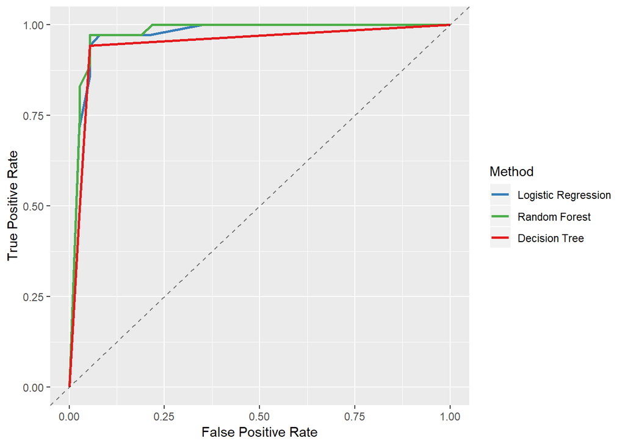

```r
plotBenchmarkRoc(bmrClassif)
```

```r
allSelectedFeatures=extractSelectedFeatureInBenchmark(bmrClassif)
kable(allSelectedFeatures)
```

| Feature | Learner | iter |
| --- | --- | --- |
| Petal.Length | classif.rpart.featsel | 1 |
| Petal.Width | classif.rpart.featsel | 1 |
| Petal.Length | classif.rpart.featsel | 2 |
| Petal.Width | classif.logreg.featsel | 1 |
| Petal.Length | classif.logreg.featsel | 2 |
| Sepal.Length | classif.randomForest.featsel | 1 |
| Petal.Width | classif.randomForest.featsel | 1 |
| Petal.Length | classif.randomForest.featsel | 2 |
| Petal.Width | classif.randomForest.featsel | 2 |

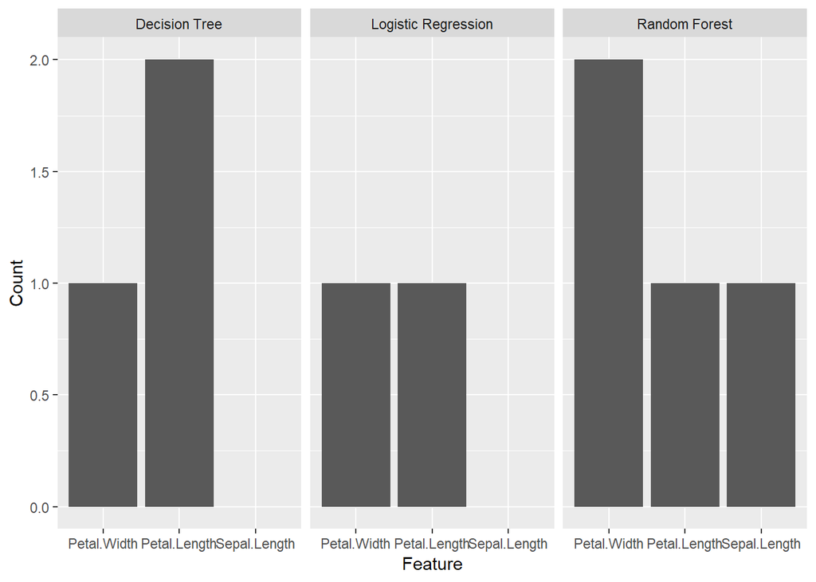

```r
plotFeatureSelectionResult(allSelectedFeatures)
```

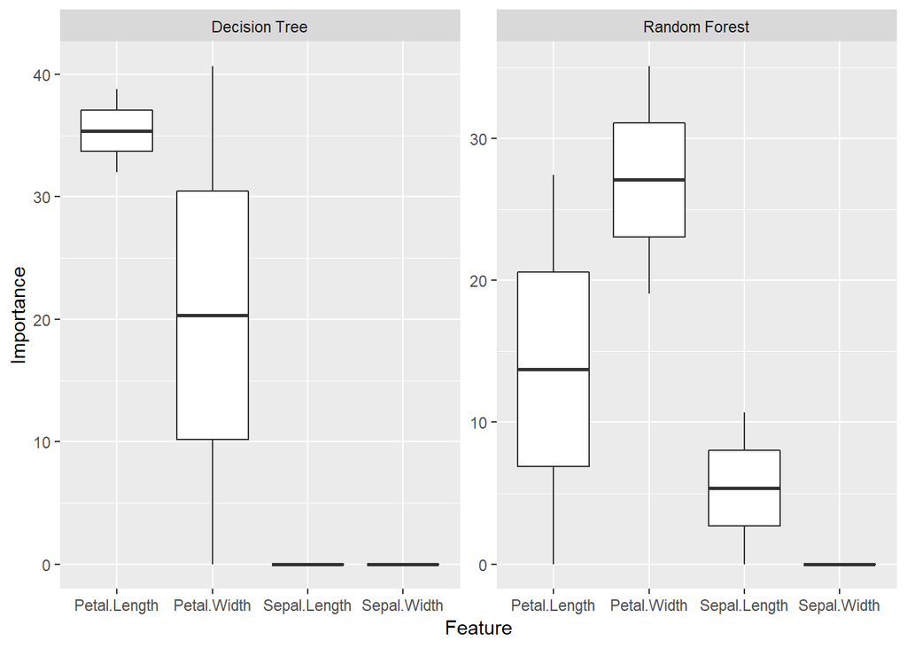

```r
featureImportance=extractFeatureImportanceInBenchmark(bmrClassif)
plotFeatureImportance(featureImportance)
```

# Parameters

## Listing classifier learners

```r
## List everything in mlr
lrns = listLearners()
head(lrns[c("class", "package")])
```

```
##                 class      package
## 1         classif.ada    ada,rpart
## 2  classif.adaboostm1        RWeka
## 3 classif.bartMachine  bartMachine
## 4    classif.binomial        stats
## 5    classif.boosting adabag,rpart
## 6         classif.bst    bst,rpart
```

```r
## List classifiers that can output probabilities
lrns = listLearners("classif", properties = "prob")
datatable(lrns[c("class", "name","twoclass","multiclass","class.weights","featimp","package")])
```

|  | class | name | twoclass | multiclass | class.weights | featimp | package |
| --- | --- | --- | --- | --- | --- | --- | --- |
| 1 | classif.ada | ada Boosting | True | False | False | False | ada,rpart |
| 2 | classif.adaboostm1 | ada Boosting M1 | True | True | False | False | RWeka |
| 3 | classif.bartMachine | Bayesian Additive Regression Trees | True | False | False | False | bartMachine |
| 4 | classif.binomial | Binomial Regression | True | False | False | False | stats |
| 5 | classif.boosting | Adabag Boosting | True | True | False | True | adabag,rpart |
| 6 | classif.C50 | C50 | True | True | False | False | C50 |
| 7 | classif.cforest | Random forest based on conditional inference trees | True | True | False | True | party |
| 8 | classif.ctree | Conditional Inference Trees | True | True | False | False | party |
| 9 | classif.cvglmnet | GLM with Lasso or Elasticnet Regularization (Cross Validated Lambda) | True | True | False | False | glmnet |
| 10 | classif.dbnDNN | Deep neural network with weights initialized by DBN | True | True | False | False | deepnet |

[output cut: 54 more lines]

## Listing survival learners

```r
## List classifiers that can output probabilities
lrns = listLearners("surv")
datatable(lrns[c("class", "name","weights","prob","featimp","package")])
```

|  | class | name | weights | prob | featimp | package |
| --- | --- | --- | --- | --- | --- | --- |
| 1 | surv.cforest | Random Forest based on Conditional Inference Trees | True | False | True | party,survival |
| 2 | surv.CoxBoost | Cox Proportional Hazards Model with Componentwise Likelihood based Boosting | True | False | False | CoxBoost |
| 3 | surv.coxph | Cox Proportional Hazard Model | True | False | False | survival |
| 4 | surv.cv.CoxBoost | Cox Proportional Hazards Model with Componentwise Likelihood based Boosting, tuned for the optimal number of boosting steps | True | False | False | CoxBoost |
| 5 | surv.cvglmnet | GLM with Regularization (Cross Validated Lambda) | True | False | False | glmnet |
| 6 | surv.gamboost | Gradient boosting with smooth components | True | False | False | survival,mboost |
| 7 | surv.gbm | Gradient Boosting Machine | True | False | True | gbm |
| 8 | surv.glmboost | Gradient Boosting with Componentwise Linear Models | True | False | False | survival,mboost |
| 9 | surv.glmnet | GLM with Regularization | True | False | False | glmnet |
| 10 | surv.randomForestSRC | Random Forest | True | False | True | survival,randomForestSRC |

[output cut: 2 more lines]

## Listing performance measures

More details at https://mlr-org.github.io/mlr-tutorial/release/html/measures/index.html

```r
## List everything in mlr
## Performance measures for classification with multiple classes
listMeasures("classif", properties = "classif.multi")
```

```
##  [1] "featperc"         "mmce"             "lsr"
##  [4] "bac"              "qsr"              "timeboth"
##  [7] "multiclass.aunp"  "timetrain"        "multiclass.aunu"
## [10] "ber"              "timepredict"      "multiclass.brier"
## [13] "ssr"              "acc"              "logloss"
## [16] "wkappa"           "multiclass.au1p"  "multiclass.au1u"
## [19] "kappa"
```

```r
## Performance measure suitable for the iris classification task
listMeasures(iris.task)
```

```
##  [1] "featperc"         "mmce"             "lsr"
##  [4] "bac"              "qsr"              "timeboth"
##  [7] "multiclass.aunp"  "timetrain"        "multiclass.aunu"
## [10] "ber"              "timepredict"      "multiclass.brier"
## [13] "ssr"              "acc"              "logloss"
## [16] "wkappa"           "multiclass.au1p"  "multiclass.au1u"
## [19] "kappa"
```

```r
## Get default measure for iris.task
getDefaultMeasure(iris.task)
```

```
## Name: Mean misclassification error
## Performance measure: mmce
## Properties: classif,classif.multi,req.pred,req.truth
## Minimize: TRUE
## Best: 0; Worst: 1
## Aggregated by: test.mean
## Arguments:
## Note: Defined as: mean(response != truth)
```

```r
## Get the default measure for linear regression
getDefaultMeasure(makeLearner("regr.lm"))
```

```
## Name: Mean of squared errors
## Performance measure: mse
## Properties: regr,req.pred,req.truth
## Minimize: TRUE
## Best: 0; Worst: Inf
## Aggregated by: test.mean
## Arguments:
## Note: Defined as: mean((response - truth)^2)
```

## Listing feature filter methods

```r
filterMethods = listFilterMethods()
datatable(filterMethods)
```

|  | id | package | desc |
| --- | --- | --- | --- |
| 1 | anova.test |  | ANOVA Test for binary and multiclass classification tasks |
| 2 | auc |  | AUC filter for binary classification tasks |
| 3 | carscore | care | CAR scores |
| 4 | cforest.importance | party | Permutation importance of random forest fitted in package 'party' |
| 5 | chi.squared | FSelector | Chi-squared statistic of independence between feature and target |
| 6 | gain.ratio | FSelector | Entropy-based gain ratio between feature and target |
| 7 | information.gain | FSelector | Entropy-based information gain between feature and target |
| 8 | kruskal.test |  | Kruskal Test for binary and multiclass classification tasks |
| 9 | linear.correlation |  | Pearson correlation between feature and target |
| 10 | mrmr | mRMRe | Minimum redundancy, maximum relevance filter |

[output cut: 12 more lines]